# Subgroup analysis

# 2018-09-19 14:30:54

Let’s re-run the analysis for different subgroups. I’ll change the code to add different cases when restricting the groups, but in some cases the different targets won’t apply.

In particular, I don’t think it’s valid to run the LCMM groups, as we’ll be removing subjects and the LCMM groups were created using all of them. I can see an aergument for doing it anyways, but for now let’s avoid it. The same idea applies to not using random slopes.

## ADHD

Here we remove anyone who is unaffected (diag_group). That leaves people in full and partial remission, as well as persistent and new_onset. We can run OLS regression, do a 3 group classification, 2 group (persistent vs remission without new onset).

```r
df = read.csv('~/data/baseline_prediction/long_clin_0918.csv')
df = df[df$diag_group != 'unaffect', ]
df$diag_group = factor(df$diag_group)
table(df$diag_group)
```

```
     full new_onset   partial   persist
       24        27        35       133
```

```r
table(df$diag_group2)
```

```
  2   3
 58 161
```

## ADHD_NOS

Here we remove anyone who is NV (DX). That leaves people who are ADHD and ADHD_NOS. In this case, the labels of remission and persistence don’t apply, so we have to categorize based on OLS slopes. We can then have 2 groups (improvers vs non-improvers), or do the OLS regression.

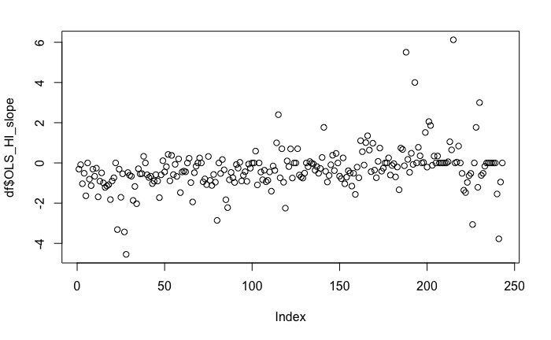

```r
df = read.csv('~/data/baseline_prediction/long_clin_0918.csv')
df = df[df$DX != 'NV', ]
plot(df$OLS_HI_slope)
```

## No new-onset

Here we remove anyone who had late-onset ADHD (diag_group). We can still run OLS slopes, and and diag_group2. If we categorize slopes we’d have 2 groups, but NV would be mixed with non-improvers. It’s still worth running it, just to compare with the entire group analysis. Or, we could also disregard NVs and just run improvers vs non-improvers.

```r
df = read.csv('~/data/baseline_prediction/long_clin_0918.csv')
df = df[df$diag_group != 'new_onset', ]
df$diag_group = factor(df$diag_group)
table(df$diag_group)
```

```
    full  partial  persist unaffect
      24       35      133      161
```

```r
table(df$diag_group2)
```

```
  1   2   3
161  58 134
```

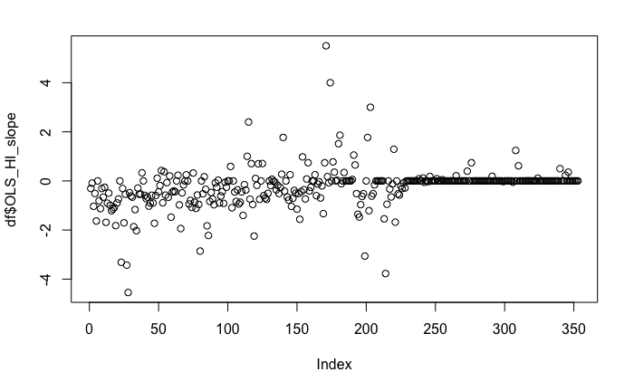

```r
plot(df$OLS_HI_slope)
```